# Personalized Drug Repositioning for IBD

Samuel Finlayson

9/6/2018

## Differential Expression

We begin by conducting a **differential expression analysis** (not shown in full, but can be found [here](http://amp.pharm.mssm.edu/biojupies/notebook/Nv1Ix3iox)) that compares gene expression measurements from affected vs unaffected components of the patient’s gastrointestinal tract.

By focusing on *functional genomics*, who hope to focus on the key differences in the behavior of cells that are flaring up and cells that are functioning normally. This differential expression analysis produces a number for each gene in the genome, which taken together forms a **signature** of the disease:

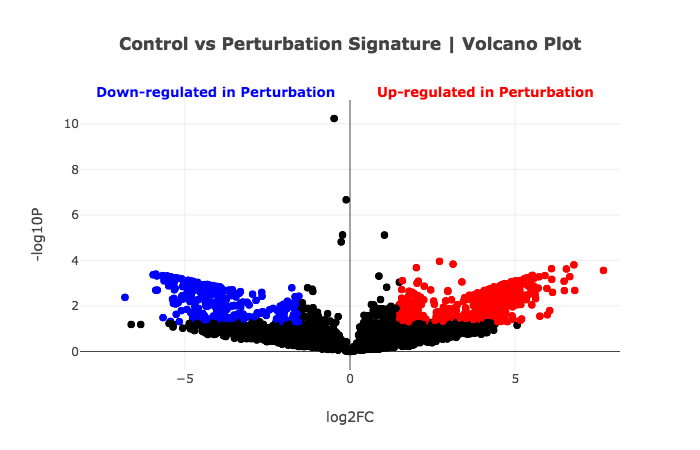

## L1000FWD Similarity Scores

The Ma’ayan Lab has released a dataset, the L1000FWD, in which they have computed gene expression signatures based on differential expression analysis before and after *perturbation* by each of some 16,000 small molecules (drugs).

In order to try to find what treatment might be useful, we compute the **cosine similarity** between the patient’s *disease signature* and the *drug signature* for each of the thousands of drugs. The result is a score between -1 and 1 for each drug, with -1 corresponding to a perfectly opposite signature and +1 corresponding to a perfectly aligned signature. Since we are looking for drugs to *reverse* the disease, we are trying to find drug signatures whose cosine similarity to the disease signature are as negative as possible.

The following plot shows the distribution of similarity scores over every drug in the dataset, along with some summary statistics:

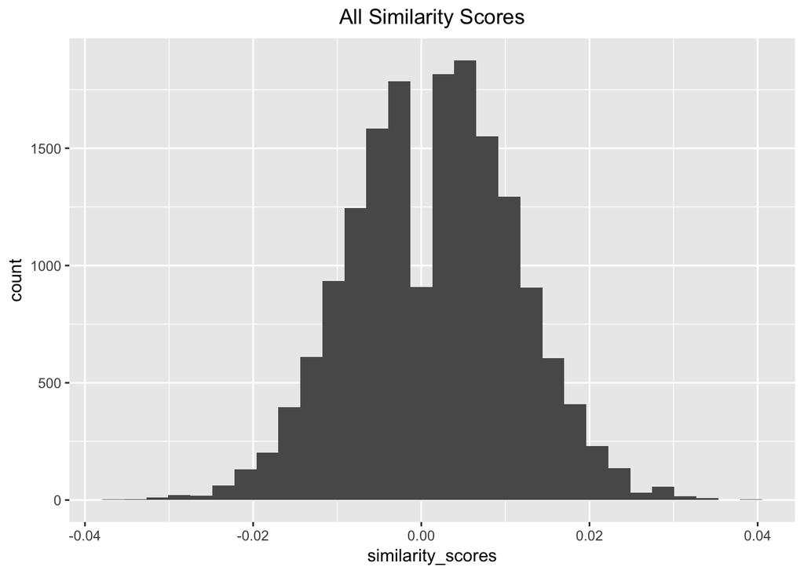

If you prefer numbers, here is a table summarising the same data:

| Min. | 1st Qu. | Median | Mean | 3rd Qu. | Max. |
| --- | --- | --- | --- | --- | --- |
| -0.03724 | -0.005517 | 0.001379 | 0.001434 | 0.008276 | 0.03862 |

## Adding confidence using the L1000CDS Similarity Scores

To refine our search, we will employ the **L1000CDS** dataset, which is a slightly older version of the same idea they implemented in the L1000FWD dataset. Since we want our findings to be as robust as possible, I will subset the L1000FWD results shown above to include only those drugs that also show up in the top 50 “best” drugs from the L1000CDS dataset.

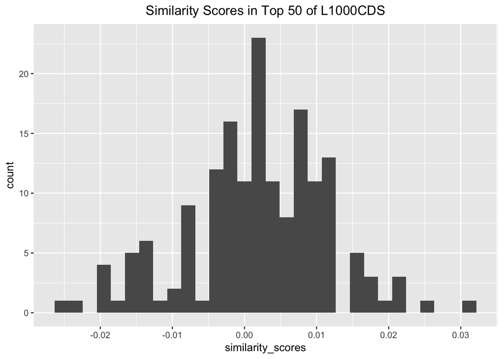

| Min. | 1st Qu. | Median | Mean | 3rd Qu. | Max. |
| --- | --- | --- | --- | --- | --- |
| -0.02621 | -0.004138 | 0.001379 | 0.001776 | 0.008276 | 0.03034 |

## Taking a closer look at the results

There are many small molecules that meet the above criteria. However, the majority of them are nameless because they have yet to be tested in clinical trials. We want drugs that have at least been shown to be safe, so I am further filtering to remove drugs that don’t have names yet.

There are 8 such drugs. Each is represented in the L1000FWD dataset many times, because they have been applied to a range of cell lines and for different durations. Here are summary states for the signature similarity scores for each drug:

| drug | Mean | Min | Max | Count |
| --- | --- | --- | --- | --- |
| selumetinib | -0.0043002 | -0.0234483 | 0.0096552 | 17 |
| torin-1 | -0.0000862 | -0.0193103 | 0.0110345 | 16 |
| geldanamycin | 0.0002069 | -0.0193103 | 0.0151724 | 20 |
| vorinostat | 0.0017241 | -0.0179310 | 0.0220690 | 20 |
| tanespimycin | 0.0017880 | -0.0262069 | 0.0206897 | 27 |
| curcumin | 0.0026860 | -0.0193103 | 0.0179310 | 19 |
| homoharringtonine | 0.0044049 | -0.0151724 | 0.0248276 | 31 |
| celastrol | 0.0056795 | -0.0068966 | 0.0303448 | 17 |

Most of these results are fairly big-gun chemotherapy agents. Filtering these out, we’re left with two compounds:

### Curcumin

Curcumin, the active ingredient in turmeric, has received a lot of attention and excitement in the context of inflammatory bowel disease. In 2015, a multicenter prospective double blind study showed that 3g per day of 95% pure curcumin added to maintenance mesalamine resulted in 53% of patients having remission. Commentary has pointed out that this was very pure curcumin and that patients should be cautious not to use supplements that may contain many impurities. Prior to the above study, a [review of two other studies in humans](https://www.ncbi.nlm.nih.gov/pubmed/21649456) found that curcumin improved response to 5-ASA and other drugs. As recently as this summer, [another systematic review](https://www.ncbi.nlm.nih.gov/pubmed/29957091) was published that found curcumin to be a promising treatment options. Curcumin also has been shown to have a number of pharmacologic mechanisms that are promising for IBD, which have been listed [here](https://www.ncbi.nlm.nih.gov/pubmed/19519446) as including “inhibitory effects on cyclooxygenases 1, 2 (COX-1, COX-2), lipoxygenase (LOX), TNF-alpha, interferon gamma (IFN-gamma), inducible nitric oxide synthase (iNOS), and the transcriptional nuclear factor kappa B (NF-kappaB), in addition to a strong anti-oxidant effects” .

I read an interesting but critical take on curcumin in general from [Derek Lowe](http://blogs.sciencemag.org/pipeline/archives/2017/01/12/curcumin-will-waste-your-time) based in large part on a perspective piece in the [journal of medicinal chemistry](https://pubs-acs-org.ezp-prod1.hul.harvard.edu/doi/abs/10.1021/acs.jmedchem.6b00975). The authors noted that curcumin has been considered a promising drug candidate for many indications but that it has many chemical properties that make it a bad drug to develop including poor bioavailability and short half-life. We should talk to a pharmacologist about these concerns in depth. However, I think it is **possible** that – because we are trying to treat the GI tract directly – the low bioavailability at least could prove to be a feature rather than a bug. Of course, we’ll need a real, live chemist to talk through the other concerns.

In short, curcumin on paper seems to be a pretty promising choice. At a minimum, it seems very safe and it has some clinical data suggesting potential effectiveness.

#### Signatures

[figure not shown]

[output not shown]

### Celastrol

[Celastrol](https://www.ncbi.nlm.nih.gov/pmc/articles/PMC5471334) is an extract from the Tripterygium wilfordii plant, which has actually been used fairly extensively in the treatment of Crohn’s disease in China (see the section “Clinical Experience with the Use of TW” in [this paper](https://www.ncbi.nlm.nih.gov/pmc/articles/PMC5471334)). TW has been studied for Crohn’s disease in clinical trials [here](https://www.ncbi.nlm.nih.gov/pubmed/19742342), [here](https://www.ncbi.nlm.nih.gov/pubmed/19296254), [here](https://www.ncbi.nlm.nih.gov/pubmed/23569144), [here](https://www.ncbi.nlm.nih.gov/pubmed/25445405), and [here](https://www.ncbi.nlm.nih.gov/pubmed/26473333). Each of the above studies found TW to help prevent relapse in Crohn’s patients, as well as or better than 5-ASA and other drugs. Celastrol has also been studied in lab in human biopsies and animal models as in [here](https://www.ncbi.nlm.nih.gov/pubmed/15336532), [here](https://www.researchgate.net/publication/297893667_A_lipidomics_investigation_into_the_intervention_of_celastrol_on_experimental_colitis), and [here](https://www.researchgate.net/publication/274723243_Celastrol_ameliorates_experimental_colitis_in_IL-10_deficient_mice_via_the_up-regulation_of_autophagy). Taken together, these suggest that TW extracts have a reasonable chance at being helpful.

Note that while Celastrol was in the top 50 most likely drugs to reverse the symptoms in the 1000CDS analysis, it was not uniformly predicted to be helpful in the 1000FWD analysis. I’m not sure why this is the case, but it is definitely something to keep in mind.

Celastrol has also been associated with some side effects that include fatigue, nausea, vomiting, diarrhea, and constipation. The review paper cited first above also points out that it has low bioavailability (which might be good for treating only the GI tract?). We would want to talk with a pharmacist to think through these issues and pick the right dosage.

#### Signatures

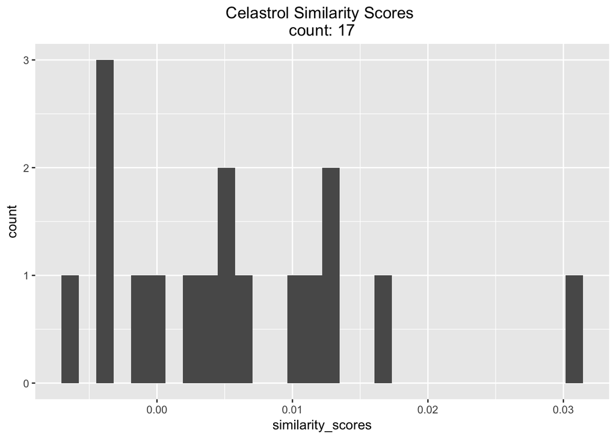

| Min. | 1st Qu. | Median | Mean | 3rd Qu. | Max. |
| --- | --- | --- | --- | --- | --- |
| -0.006897 | -0.001379 | 0.005517 | 0.00568 | 0.01103 | 0.03034 |